# adversarial auto-encoder AAE

## Final Project: Using Adversarial Auto Encoders(AAE) to determine the cultural influence of ancient civilizations

### Authors: Jes ́us Alejandro de Leon Moreno, Yasm ́ın Alejandra Femerling Garc ́ıa, Ishna Satyarth

### 1. Overview:

Images of sculptures from Achaemenid, Classi-cal Greek and Hellenistic, Hellenistic Babylonyan, and Neo-Babylonian cultures from the Department of Art History of SMU,Dallas were encoded using an Adversarial Auto-Encoder into a latent 2D space to determine if Hellenistic Babylonyan art has cultural influence from Classical Greek, Neo-Babylonian, or Achaemenid art. Although the results are difficult to interpret,they can be used to help with the subjective resolution of artband historic research in the matter and to set ground to futurework

#### 1.1 AAE Description:

In adversarial autoencoder, a GAN performs variational inference by matching the hidden code vector of the autoencoder with a prior distribution. This can be used to map the input images into a model that follows a specified distribution, yielding a latent space that can be visualized in a 2D graph. The autoencoder is trained with a dual objective, one is the reconstruction as a traditional autoencoder, and the other is the adverserial training that matches the distribution of the latent representation of the autoencoder to an arbitrary prior distribution. The encoder learns to convert the data distribution to the prior distribution, and the decoder learns a deep generative model that maps the prior distribution to the data distribution. The adverserial autoencoders are useful in applications such as semi-supervised classification, disentangling style and content of images, unsupervised clustering, dimensionality reductionand data visualization.

Importing the necessary libraries.

```python
import numpy as np
import random
import torch
import torch.nn as nn
import torch.nn.parallel
import torch.backends.cudnn as cudnn
import torch.optim as optim
import torch.utils.data
import torch.nn.functional as F

import torchvision
import torchvision.datasets as dset
import torchvision.transforms as transforms
import torchvision.utils as vutils
import torch.autograd as autograd
from torch.autograd import Variable
import torchvision.datasets

import matplotlib.pyplot as plt
import matplotlib.animation as animation
from IPython.display import HTML
from matplotlib import gridspec
import matplotlib.patches as mpatches
```

```python
# Initializing the variables for input
batch_size = 100
height = 256
width = 256
channels = 3
input_dim = height * width * channels

#Initializing variables for the model
nl1 = 1000
nl2 = 1000
z_dim = 2

# We will perform 200 epochs with batch-size of 100 and learning rate of 0.001
batch_size = 100
EPOCHS = 200
learning_rate = 0.001
beta1 = 0.9

torch.autograd.set_detect_anomaly(True)

#Normalization helps get data within a range and reduces the skewness which helps learn faster and better
dataset = torchvision.datasets.ImageFolder('data', transform=transforms.Compose([
                           transforms.Resize((height,width)),
                           transforms.ToTensor(),
                           transforms.Normalize((0.5, 0.5, 0.5), (0.5, 0.5, 0.5))
                       ]))

#This allows easier implementations of chunk-reading and dynamic batch size
dataloader = torch.utils.data.DataLoader(dataset, batch_size=batch_size,
                                         shuffle=True, num_workers=0)
```

#### 1.2 Implementing AAE

We have created the Encoder, Decoder, Discriminator and AutoEncoder classes

```python
#Building model

#Build Encoder
#Used linear model with 3 dense layers and Relu activation function
class Encoder(nn.Module):

    def __init__(self):
        super(Encoder, self).__init__()
        self.dense1= nn.Linear(input_dim, nl1)
        self.dense2 = nn.Linear(nl1, nl2)
        self.dense3 = nn.Linear(nl2, z_dim)


    def forward(self, x):
        x = F.relu(self.dense1(x))
        x = F.relu(self.dense2(x))
        x = self.dense3(x)
        return x

#Build Decoder
#Used linear model with 3 dense layers and Relu and Sigmoid activation function
class Decoder(nn.Module):

    def __init__(self):
        super(Decoder, self).__init__()
        self.dense1= nn.Linear(z_dim, nl2)
        self.dense2 = nn.Linear(nl2, nl1)
        self.dense3 = nn.Linear(nl1, input_dim)


    def forward(self, x):
        x = F.relu(self.dense1(x))
        x = F.relu(self.dense2(x))
        x = F.sigmoid(self.dense3(x))
        return x

#Build Discriminator
#Used linear model with 3 dense layers and Relu and Sigmoid activation function
class Discriminator(nn.Module):

    def __init__(self):
        super(Discriminator, self).__init__()
        self.dense1= nn.Linear(z_dim, nl1)
        self.dense2 = nn.Linear(nl1, nl2)
        self.dense3 = nn.Linear(nl2, 1)


    def forward(self, x):
        x = F.relu(self.dense1(x))
        x = F.relu(self.dense2(x))
        x = F.sigmoid(self.dense3(x))
        return x

#Build AutoEncoder
class AutoEncoder(nn.Module):
    def __init__(self, coder, decoder):
        super(AutoEncoder, self).__init__()
        self.coder = coder
        self.decoder = decoder

    def forward(self, x):
        x = self.coder(x)
        x = self.decoder(x)
        return x
```

#### Implemention the Adversarial Auto-Encoder model

```python
# Initialization
encoder = Encoder()
decoder = Decoder()
discriminator = Discriminator()
autoencoder = AutoEncoder(encoder,decoder)

autoencoder_optimizer = torch.optim.Adam(autoencoder.parameters())
discriminator_optimizer = torch.optim.Adam(discriminator.parameters())
encoder_optimizer = torch.optim.Adam(encoder.parameters())

# Calculating the Loss Function
loss_fct = torch.nn.BCELoss()
```

```python
# Plotting the Images in a Latent Space form
def generate_image_grid(step):

    X = imgs
    Y = y_imgs

    x_test = torch.reshape(X, [-1,input_dim])
    # Latent space of test set
    x_test_encoded = encoder(x_test).detach().numpy()
    label_list = Y
    fig = plt.figure(figsize=(10,10))
    classes = dataset.classes
    colormap = plt.cm.rainbow(np.linspace(0, 1, len(classes)))
    kwargs = {'alpha': 0.8, 'c': [colormap[i] for i in label_list]}
    handles = [mpatches.Circle((0, 0), label=class_, color=colormap[i])
               for i, class_ in enumerate(classes)]
    plt.legend(handles=handles, shadow=True, fancybox=True, loc='center left')
    plt.scatter(x_test_encoded[:, 0], x_test_encoded[:, 1], s=25, **kwargs)
    plt.grid()
    plt.show()
    fig.suptitle('Epoch {} Latent Space'.format(step+1), fontsize=16)
    fig.savefig('res_imgs/Result_from_step_{}.png'.format(step+1))
```

```python
# Plotting the Final Output
def generate_image_grid_final(name):
    fig = plt.figure(figsize=(10,10))
    first_batch = []
    for step_graph, (X, Y) in enumerate(dataloader):
        x_test = torch.reshape(X, [-1,input_dim])
        # Latent space of test set
        x_test_encoded = encoder(x_test).detach().numpy()
        label_list = Y
        classes = dataset.classes
        colormap = plt.cm.rainbow(np.linspace(0, 1, len(classes)))
        kwargs = {'alpha': 0.8, 'c': [colormap[i] for i in label_list]}
        handles = [mpatches.Circle((0, 0), label=class_, color=colormap[i])
                   for i, class_ in enumerate(classes)]
        plt.legend(handles=handles, shadow=True, fancybox=True, loc='center left')
        plt.scatter(x_test_encoded[:, 0], x_test_encoded[:, 1], s=25, **kwargs)
        holder = np.where(np.logical_and(x_test_encoded[:, 0] < -2000, x_test_encoded[:, 0] > -10000))
        first_batch.append(X[holder,:,:,:])
    plt.grid()
    plt.show()
    fig.suptitle('Final Epoch Latent Space', fontsize=16)
    fig.savefig('res_imgs/Result_from_final_{}.png'.format(name))
    return first_batch
```

```python
def get_range(upper, lower):
    first_batch = []
    for step_graph, (X, Y) in enumerate(dataloader):
        x_test = torch.reshape(X, [-1,input_dim])
        # Latent space of test set
        x_test_encoded = encoder(x_test).detach().numpy()
        holder = np.where(np.logical_and(x_test_encoded[:, 0] < upper, x_test_encoded[:, 0] > lower))
        first_batch.append(X[holder,:,:,:])
    return first_batch
```

```
c:\program files\python38\lib\site-packages\torch\nn\functional.py:1709: UserWarning: nn.functional.sigmoid is deprecated. Use torch.sigmoid instead.
  warnings.warn("nn.functional.sigmoid is deprecated. Use torch.sigmoid instead.")
```

```
EPOCH   1/ 200: AE_LOSS: 0.2350 DC_LOSS: 100.0000 GEN_LOSS: 0.0000
```

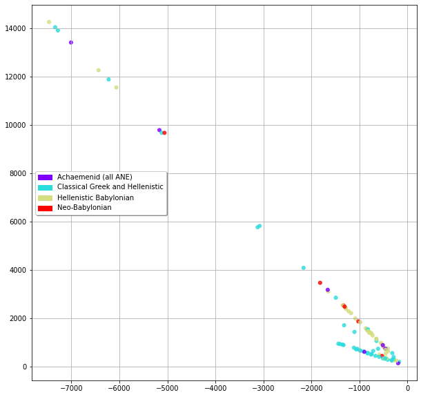

```
EPOCH   2/ 200: AE_LOSS: 0.2179 DC_LOSS: 100.0000 GEN_LOSS: 0.0000
EPOCH   3/ 200: AE_LOSS: 0.2573 DC_LOSS: 100.0000 GEN_LOSS: 0.0000
EPOCH   4/ 200: AE_LOSS: 0.2424 DC_LOSS: 100.0000 GEN_LOSS: 0.0000
EPOCH   5/ 200: AE_LOSS: 0.2565 DC_LOSS: 100.0000 GEN_LOSS: 0.0000
EPOCH   6/ 200: AE_LOSS: 0.2669 DC_LOSS: 100.0000 GEN_LOSS: 0.0000
EPOCH   7/ 200: AE_LOSS: 0.2020 DC_LOSS: 100.0000 GEN_LOSS: 0.0000
EPOCH   8/ 200: AE_LOSS: 0.2514 DC_LOSS: 100.0000 GEN_LOSS: 0.0000
EPOCH   9/ 200: AE_LOSS: 0.2361 DC_LOSS: 100.0000 GEN_LOSS: 0.0000
EPOCH  10/ 200: AE_LOSS: 0.1992 DC_LOSS: 100.0000 GEN_LOSS: 0.0000
EPOCH  11/ 200: AE_LOSS: 0.2398 DC_LOSS: 100.0000 GEN_LOSS: 0.0000
EPOCH  12/ 200: AE_LOSS: 0.2348 DC_LOSS: 100.0000 GEN_LOSS: 0.0000
EPOCH  13/ 200: AE_LOSS: 0.2465 DC_LOSS: 100.0000 GEN_LOSS: 0.0000
EPOCH  14/ 200: AE_LOSS: 0.2162 DC_LOSS: 100.0000 GEN_LOSS: 0.0000
EPOCH  15/ 200: AE_LOSS: 0.2400 DC_LOSS: 100.0000 GEN_LOSS: 0.0000
EPOCH  16/ 200: AE_LOSS: 0.2149 DC_LOSS: 100.0000 GEN_LOSS: 0.0000
EPOCH  17/ 200: AE_LOSS: 0.2325 DC_LOSS: 100.0000 GEN_LOSS: 0.0000
EPOCH  18/ 200: AE_LOSS: 0.2635 DC_LOSS: 100.0000 GEN_LOSS: 0.0000
EPOCH  19/ 200: AE_LOSS: 0.2794 DC_LOSS: 100.0000 GEN_LOSS: 0.0000
EPOCH  20/ 200: AE_LOSS: 0.2644 DC_LOSS: 100.0000 GEN_LOSS: 0.0000
EPOCH  21/ 200: AE_LOSS: 0.2560 DC_LOSS: 100.0000 GEN_LOSS: 0.0000
```

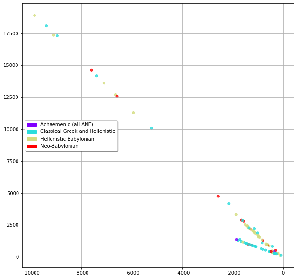

```
EPOCH  22/ 200: AE_LOSS: 0.2593 DC_LOSS: 100.0000 GEN_LOSS: 0.0000
EPOCH  23/ 200: AE_LOSS: 0.2204 DC_LOSS: 100.0000 GEN_LOSS: 0.0000
EPOCH  24/ 200: AE_LOSS: 0.2646 DC_LOSS: 100.0000 GEN_LOSS: 0.0000
EPOCH  25/ 200: AE_LOSS: 0.2126 DC_LOSS: 100.0000 GEN_LOSS: 0.0000
EPOCH  26/ 200: AE_LOSS: 0.2911 DC_LOSS: 100.0000 GEN_LOSS: 0.0000
EPOCH  27/ 200: AE_LOSS: 0.2479 DC_LOSS: 100.0000 GEN_LOSS: 0.0000
EPOCH  28/ 200: AE_LOSS: 0.2222 DC_LOSS: 100.0000 GEN_LOSS: 0.0000
EPOCH  29/ 200: AE_LOSS: 0.2728 DC_LOSS: 100.0000 GEN_LOSS: 0.0000
EPOCH  30/ 200: AE_LOSS: 0.2331 DC_LOSS: 100.0000 GEN_LOSS: 0.0000
EPOCH  31/ 200: AE_LOSS: 0.2415 DC_LOSS: 100.0000 GEN_LOSS: 0.0000
EPOCH  32/ 200: AE_LOSS: 0.2476 DC_LOSS: 100.0000 GEN_LOSS: 0.0000
EPOCH  33/ 200: AE_LOSS: 0.2139 DC_LOSS: 100.0000 GEN_LOSS: 0.0000
EPOCH  34/ 200: AE_LOSS: 0.2373 DC_LOSS: 100.0000 GEN_LOSS: 0.0000
EPOCH  35/ 200: AE_LOSS: 0.2260 DC_LOSS: 100.0000 GEN_LOSS: 0.0000
EPOCH  36/ 200: AE_LOSS: 0.2292 DC_LOSS: 100.0000 GEN_LOSS: 0.0000
EPOCH  37/ 200: AE_LOSS: 0.2461 DC_LOSS: 100.0000 GEN_LOSS: 0.0000
EPOCH  38/ 200: AE_LOSS: 0.2326 DC_LOSS: 100.0000 GEN_LOSS: 0.0000
EPOCH  39/ 200: AE_LOSS: 0.2486 DC_LOSS: 100.0000 GEN_LOSS: 0.0000
EPOCH  40/ 200: AE_LOSS: 0.2416 DC_LOSS: 100.0000 GEN_LOSS: 0.0000
EPOCH  41/ 200: AE_LOSS: 0.2149 DC_LOSS: 100.0000 GEN_LOSS: 0.0000
```

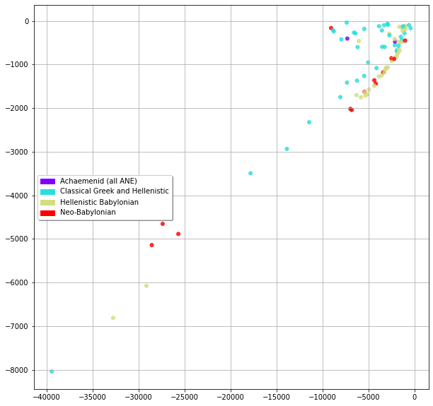

```
EPOCH  42/ 200: AE_LOSS: 0.2338 DC_LOSS: 100.0000 GEN_LOSS: 0.0000
EPOCH  43/ 200: AE_LOSS: 0.2631 DC_LOSS: 100.0000 GEN_LOSS: 0.0000
EPOCH  44/ 200: AE_LOSS: 0.2035 DC_LOSS: 100.0000 GEN_LOSS: 0.0000
EPOCH  45/ 200: AE_LOSS: 0.2186 DC_LOSS: 100.0000 GEN_LOSS: 0.0000
EPOCH  46/ 200: AE_LOSS: 0.2664 DC_LOSS: 100.0000 GEN_LOSS: 0.0000
EPOCH  47/ 200: AE_LOSS: 0.2388 DC_LOSS: 100.0000 GEN_LOSS: 0.0000
EPOCH  48/ 200: AE_LOSS: 0.2073 DC_LOSS: 100.0000 GEN_LOSS: 0.0000
EPOCH  49/ 200: AE_LOSS: 0.2481 DC_LOSS: 100.0000 GEN_LOSS: 0.0000
EPOCH  50/ 200: AE_LOSS: 0.2408 DC_LOSS: 100.0000 GEN_LOSS: 0.0000
EPOCH  51/ 200: AE_LOSS: 0.2140 DC_LOSS: 100.0000 GEN_LOSS: 0.0000
EPOCH  52/ 200: AE_LOSS: 0.2339 DC_LOSS: 100.0000 GEN_LOSS: 0.0000
EPOCH  53/ 200: AE_LOSS: 0.2404 DC_LOSS: 100.0000 GEN_LOSS: 0.0000
EPOCH  54/ 200: AE_LOSS: 0.2305 DC_LOSS: 100.0000 GEN_LOSS: 0.0000
EPOCH  55/ 200: AE_LOSS: 0.2573 DC_LOSS: 100.0000 GEN_LOSS: 0.0000
EPOCH  56/ 200: AE_LOSS: 0.2443 DC_LOSS: 100.0000 GEN_LOSS: 0.0000
EPOCH  57/ 200: AE_LOSS: 0.2143 DC_LOSS: 100.0000 GEN_LOSS: 0.0000
EPOCH  58/ 200: AE_LOSS: 0.2232 DC_LOSS: 100.0000 GEN_LOSS: 0.0000
EPOCH  59/ 200: AE_LOSS: 0.2409 DC_LOSS: 100.0000 GEN_LOSS: 0.0000
EPOCH  60/ 200: AE_LOSS: 0.2527 DC_LOSS: 100.0000 GEN_LOSS: 0.0000
EPOCH  61/ 200: AE_LOSS: 0.2331 DC_LOSS: 100.0000 GEN_LOSS: 0.0000
```

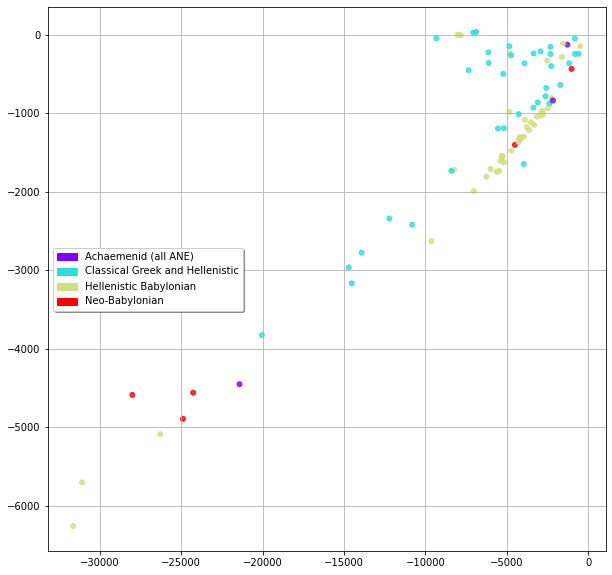

```
EPOCH  62/ 200: AE_LOSS: 0.2110 DC_LOSS: 100.0000 GEN_LOSS: 0.0000
EPOCH  63/ 200: AE_LOSS: 0.2362 DC_LOSS: 100.0000 GEN_LOSS: 0.0000
EPOCH  64/ 200: AE_LOSS: 0.2750 DC_LOSS: 100.0000 GEN_LOSS: 0.0000
EPOCH  65/ 200: AE_LOSS: 0.2539 DC_LOSS: 100.0000 GEN_LOSS: 0.0000
EPOCH  66/ 200: AE_LOSS: 0.2062 DC_LOSS: 100.0000 GEN_LOSS: 0.0000
EPOCH  67/ 200: AE_LOSS: 0.2513 DC_LOSS: 100.0000 GEN_LOSS: 0.0000
EPOCH  68/ 200: AE_LOSS: 0.2760 DC_LOSS: 100.0000 GEN_LOSS: 0.0000
EPOCH  69/ 200: AE_LOSS: 0.2336 DC_LOSS: 100.0000 GEN_LOSS: 0.0000
EPOCH  70/ 200: AE_LOSS: 0.2210 DC_LOSS: 100.0000 GEN_LOSS: 0.0000
EPOCH  71/ 200: AE_LOSS: 0.1970 DC_LOSS: 100.0000 GEN_LOSS: 0.0000
EPOCH  72/ 200: AE_LOSS: 0.2334 DC_LOSS: 100.0000 GEN_LOSS: 0.0000
EPOCH  73/ 200: AE_LOSS: 0.2247 DC_LOSS: 100.0000 GEN_LOSS: 0.0000
EPOCH  74/ 200: AE_LOSS: 0.2279 DC_LOSS: 100.0000 GEN_LOSS: 0.0000
EPOCH  75/ 200: AE_LOSS: 0.2358 DC_LOSS: 100.0000 GEN_LOSS: 0.0000
EPOCH  76/ 200: AE_LOSS: 0.2746 DC_LOSS: 100.0000 GEN_LOSS: 0.0000
EPOCH  77/ 200: AE_LOSS: 0.2408 DC_LOSS: 100.0000 GEN_LOSS: 0.0000
EPOCH  78/ 200: AE_LOSS: 0.2107 DC_LOSS: 100.0000 GEN_LOSS: 0.0000
EPOCH  79/ 200: AE_LOSS: 0.2801 DC_LOSS: 100.0000 GEN_LOSS: 0.0000
EPOCH  80/ 200: AE_LOSS: 0.2944 DC_LOSS: 100.0000 GEN_LOSS: 0.0000
EPOCH  81/ 200: AE_LOSS: 0.2387 DC_LOSS: 100.0000 GEN_LOSS: 0.0000
```

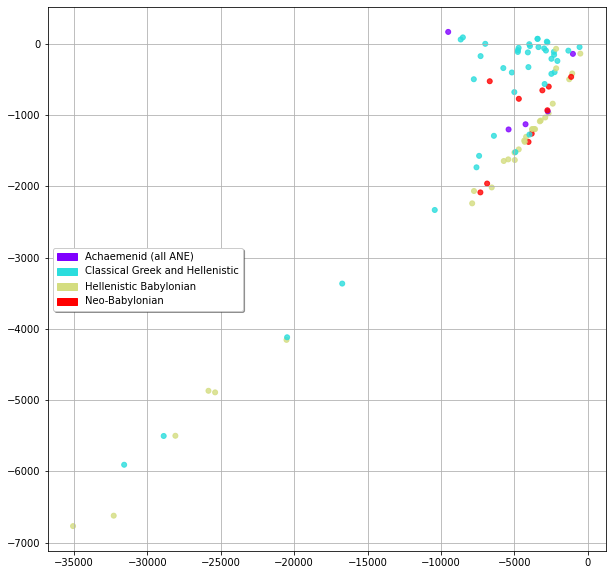

```
EPOCH  82/ 200: AE_LOSS: 0.2332 DC_LOSS: 100.0000 GEN_LOSS: 0.0000
EPOCH  83/ 200: AE_LOSS: 0.2343 DC_LOSS: 100.0000 GEN_LOSS: 0.0000
EPOCH  84/ 200: AE_LOSS: 0.2566 DC_LOSS: 100.0000 GEN_LOSS: 0.0000
EPOCH  85/ 200: AE_LOSS: 0.2662 DC_LOSS: 100.0000 GEN_LOSS: 0.0000
EPOCH  86/ 200: AE_LOSS: 0.2193 DC_LOSS: 100.0000 GEN_LOSS: 0.0000
EPOCH  87/ 200: AE_LOSS: 0.1909 DC_LOSS: 100.0000 GEN_LOSS: 0.0000
EPOCH  88/ 200: AE_LOSS: 0.2652 DC_LOSS: 100.0000 GEN_LOSS: 0.0000
EPOCH  89/ 200: AE_LOSS: 0.2449 DC_LOSS: 100.0000 GEN_LOSS: 0.0000
EPOCH  90/ 200: AE_LOSS: 0.2305 DC_LOSS: 100.0000 GEN_LOSS: 0.0000
EPOCH  91/ 200: AE_LOSS: 0.2481 DC_LOSS: 100.0000 GEN_LOSS: 0.0000
EPOCH  92/ 200: AE_LOSS: 0.2249 DC_LOSS: 100.0000 GEN_LOSS: 0.0000
EPOCH  93/ 200: AE_LOSS: 0.2255 DC_LOSS: 100.0000 GEN_LOSS: 0.0000
EPOCH  94/ 200: AE_LOSS: 0.2197 DC_LOSS: 100.0000 GEN_LOSS: 0.0000
EPOCH  95/ 200: AE_LOSS: 0.2174 DC_LOSS: 100.0000 GEN_LOSS: 0.0000
EPOCH  96/ 200: AE_LOSS: 0.2004 DC_LOSS: 100.0000 GEN_LOSS: 0.0000
EPOCH  97/ 200: AE_LOSS: 0.2324 DC_LOSS: 100.0000 GEN_LOSS: 0.0000
EPOCH  98/ 200: AE_LOSS: 0.2544 DC_LOSS: 100.0000 GEN_LOSS: 0.0000
EPOCH  99/ 200: AE_LOSS: 0.2461 DC_LOSS: 100.0000 GEN_LOSS: 0.0000
EPOCH 100/ 200: AE_LOSS: 0.2526 DC_LOSS: 100.0000 GEN_LOSS: 0.0000
EPOCH 101/ 200: AE_LOSS: 0.2302 DC_LOSS: 100.0000 GEN_LOSS: 0.0000
```

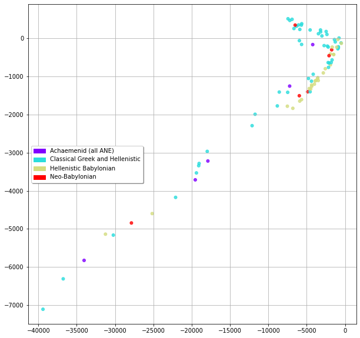

```
EPOCH 102/ 200: AE_LOSS: 0.2077 DC_LOSS: 100.0000 GEN_LOSS: 0.0000
EPOCH 103/ 200: AE_LOSS: 0.2344 DC_LOSS: 100.0000 GEN_LOSS: 0.0000
EPOCH 104/ 200: AE_LOSS: 0.2282 DC_LOSS: 100.0000 GEN_LOSS: 0.0000
EPOCH 105/ 200: AE_LOSS: 0.2207 DC_LOSS: 100.0000 GEN_LOSS: 0.0000
EPOCH 106/ 200: AE_LOSS: 0.2356 DC_LOSS: 100.0000 GEN_LOSS: 0.0000
EPOCH 107/ 200: AE_LOSS: 0.2205 DC_LOSS: 100.0000 GEN_LOSS: 0.0000
EPOCH 108/ 200: AE_LOSS: 0.2314 DC_LOSS: 100.0000 GEN_LOSS: 0.0000
EPOCH 109/ 200: AE_LOSS: 0.2269 DC_LOSS: 100.0000 GEN_LOSS: 0.0000
EPOCH 110/ 200: AE_LOSS: 0.2477 DC_LOSS: 100.0000 GEN_LOSS: 0.0000
EPOCH 111/ 200: AE_LOSS: 0.2373 DC_LOSS: 100.0000 GEN_LOSS: 0.0000
EPOCH 112/ 200: AE_LOSS: 0.2762 DC_LOSS: 100.0000 GEN_LOSS: 0.0000
EPOCH 113/ 200: AE_LOSS: 0.2178 DC_LOSS: 100.0000 GEN_LOSS: 0.0000
EPOCH 114/ 200: AE_LOSS: 0.2269 DC_LOSS: 100.0000 GEN_LOSS: 0.0000
EPOCH 115/ 200: AE_LOSS: 0.2556 DC_LOSS: 100.0000 GEN_LOSS: 0.0000
EPOCH 116/ 200: AE_LOSS: 0.2345 DC_LOSS: 100.0000 GEN_LOSS: 0.0000
EPOCH 117/ 200: AE_LOSS: 0.2367 DC_LOSS: 100.0000 GEN_LOSS: 0.0000
EPOCH 118/ 200: AE_LOSS: 0.2371 DC_LOSS: 100.0000 GEN_LOSS: 0.0000
EPOCH 119/ 200: AE_LOSS: 0.2469 DC_LOSS: 100.0000 GEN_LOSS: 0.0000
EPOCH 120/ 200: AE_LOSS: 0.2250 DC_LOSS: 100.0000 GEN_LOSS: 0.0000
EPOCH 121/ 200: AE_LOSS: 0.2392 DC_LOSS: 100.0000 GEN_LOSS: 0.0000
```

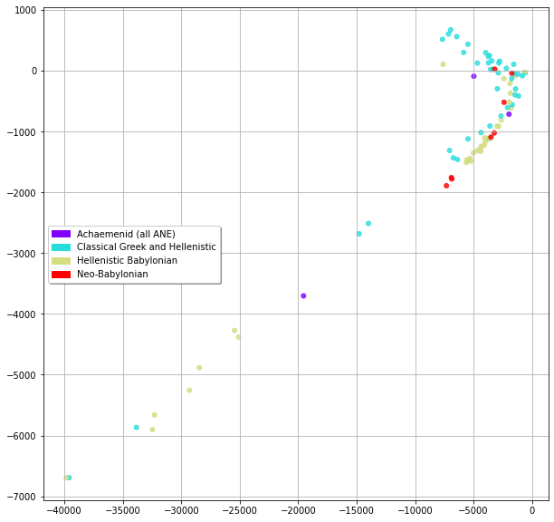

```
EPOCH 122/ 200: AE_LOSS: 0.2366 DC_LOSS: 100.0000 GEN_LOSS: 0.0000
EPOCH 123/ 200: AE_LOSS: 0.2494 DC_LOSS: 100.0000 GEN_LOSS: 0.0000
EPOCH 124/ 200: AE_LOSS: 0.2227 DC_LOSS: 100.0000 GEN_LOSS: 0.0000
EPOCH 125/ 200: AE_LOSS: 0.2478 DC_LOSS: 100.0000 GEN_LOSS: 0.0000
EPOCH 126/ 200: AE_LOSS: 0.2250 DC_LOSS: 100.0000 GEN_LOSS: 0.0000
EPOCH 127/ 200: AE_LOSS: 0.2528 DC_LOSS: 100.0000 GEN_LOSS: 0.0000
EPOCH 128/ 200: AE_LOSS: 0.1984 DC_LOSS: 100.0000 GEN_LOSS: 0.0000
EPOCH 129/ 200: AE_LOSS: 0.2499 DC_LOSS: 100.0000 GEN_LOSS: 0.0000
EPOCH 130/ 200: AE_LOSS: 0.2453 DC_LOSS: 100.0000 GEN_LOSS: 0.0000
EPOCH 131/ 200: AE_LOSS: 0.2358 DC_LOSS: 100.0000 GEN_LOSS: 0.0000
EPOCH 132/ 200: AE_LOSS: 0.2468 DC_LOSS: 100.0000 GEN_LOSS: 0.0000
EPOCH 133/ 200: AE_LOSS: 0.2367 DC_LOSS: 100.0000 GEN_LOSS: 0.0000
EPOCH 134/ 200: AE_LOSS: 0.2592 DC_LOSS: 100.0000 GEN_LOSS: 0.0000
EPOCH 135/ 200: AE_LOSS: 0.2528 DC_LOSS: 100.0000 GEN_LOSS: 0.0000
EPOCH 136/ 200: AE_LOSS: 0.2210 DC_LOSS: 100.0000 GEN_LOSS: 0.0000
EPOCH 137/ 200: AE_LOSS: 0.2471 DC_LOSS: 100.0000 GEN_LOSS: 0.0000
EPOCH 138/ 200: AE_LOSS: 0.2111 DC_LOSS: 100.0000 GEN_LOSS: 0.0000
EPOCH 139/ 200: AE_LOSS: 0.2387 DC_LOSS: 100.0000 GEN_LOSS: 0.0000
EPOCH 140/ 200: AE_LOSS: 0.2195 DC_LOSS: 100.0000 GEN_LOSS: 0.0000
EPOCH 141/ 200: AE_LOSS: 0.2126 DC_LOSS: 100.0000 GEN_LOSS: 0.0000
```

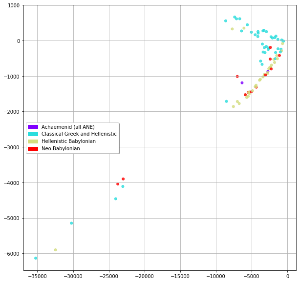

```
EPOCH 142/ 200: AE_LOSS: 0.1891 DC_LOSS: 100.0000 GEN_LOSS: 0.0000
EPOCH 143/ 200: AE_LOSS: 0.2141 DC_LOSS: 100.0000 GEN_LOSS: 0.0000
EPOCH 144/ 200: AE_LOSS: 0.1989 DC_LOSS: 100.0000 GEN_LOSS: 0.0000
EPOCH 145/ 200: AE_LOSS: 0.2236 DC_LOSS: 100.0000 GEN_LOSS: 0.0000
EPOCH 146/ 200: AE_LOSS: 0.2521 DC_LOSS: 100.0000 GEN_LOSS: 0.0000
EPOCH 147/ 200: AE_LOSS: 0.2376 DC_LOSS: 100.0000 GEN_LOSS: 0.0000
EPOCH 148/ 200: AE_LOSS: 0.2404 DC_LOSS: 100.0000 GEN_LOSS: 0.0000
EPOCH 149/ 200: AE_LOSS: 0.2307 DC_LOSS: 100.0000 GEN_LOSS: 0.0000
EPOCH 150/ 200: AE_LOSS: 0.2695 DC_LOSS: 100.0000 GEN_LOSS: 0.0000
EPOCH 151/ 200: AE_LOSS: 0.2445 DC_LOSS: 100.0000 GEN_LOSS: 0.0000
EPOCH 152/ 200: AE_LOSS: 0.1929 DC_LOSS: 100.0000 GEN_LOSS: 0.0000
EPOCH 153/ 200: AE_LOSS: 0.2201 DC_LOSS: 100.0000 GEN_LOSS: 0.0000
EPOCH 154/ 200: AE_LOSS: 0.2366 DC_LOSS: 100.0000 GEN_LOSS: 0.0000
EPOCH 155/ 200: AE_LOSS: 0.2404 DC_LOSS: 100.0000 GEN_LOSS: 0.0000
EPOCH 156/ 200: AE_LOSS: 0.2190 DC_LOSS: 100.0000 GEN_LOSS: 0.0000
EPOCH 157/ 200: AE_LOSS: 0.2657 DC_LOSS: 100.0000 GEN_LOSS: 0.0000
EPOCH 158/ 200: AE_LOSS: 0.2300 DC_LOSS: 100.0000 GEN_LOSS: 0.0000
EPOCH 159/ 200: AE_LOSS: 0.2218 DC_LOSS: 100.0000 GEN_LOSS: 0.0000
EPOCH 160/ 200: AE_LOSS: 0.2257 DC_LOSS: 100.0000 GEN_LOSS: 0.0000
EPOCH 161/ 200: AE_LOSS: 0.2497 DC_LOSS: 100.0000 GEN_LOSS: 0.0000
```

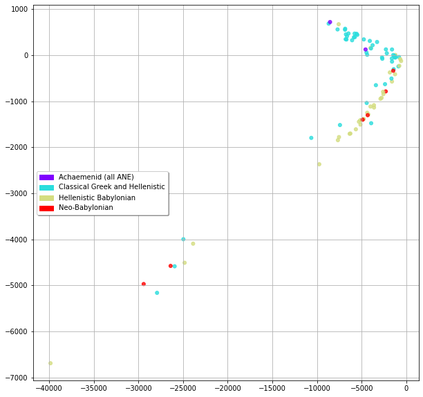

```
EPOCH 162/ 200: AE_LOSS: 0.2444 DC_LOSS: 100.0000 GEN_LOSS: 0.0000
EPOCH 163/ 200: AE_LOSS: 0.2374 DC_LOSS: 100.0000 GEN_LOSS: 0.0000
EPOCH 164/ 200: AE_LOSS: 0.2237 DC_LOSS: 100.0000 GEN_LOSS: 0.0000
EPOCH 165/ 200: AE_LOSS: 0.2406 DC_LOSS: 100.0000 GEN_LOSS: 0.0000
EPOCH 166/ 200: AE_LOSS: 0.2543 DC_LOSS: 100.0000 GEN_LOSS: 0.0000
EPOCH 167/ 200: AE_LOSS: 0.2694 DC_LOSS: 100.0000 GEN_LOSS: 0.0000
EPOCH 168/ 200: AE_LOSS: 0.2629 DC_LOSS: 100.0000 GEN_LOSS: 0.0000
EPOCH 169/ 200: AE_LOSS: 0.2176 DC_LOSS: 100.0000 GEN_LOSS: 0.0000
EPOCH 170/ 200: AE_LOSS: 0.2120 DC_LOSS: 100.0000 GEN_LOSS: 0.0000
EPOCH 171/ 200: AE_LOSS: 0.2650 DC_LOSS: 100.0000 GEN_LOSS: 0.0000
EPOCH 172/ 200: AE_LOSS: 0.2715 DC_LOSS: 100.0000 GEN_LOSS: 0.0000
EPOCH 173/ 200: AE_LOSS: 0.2359 DC_LOSS: 100.0000 GEN_LOSS: 0.0000
EPOCH 174/ 200: AE_LOSS: 0.2293 DC_LOSS: 100.0000 GEN_LOSS: 0.0000
EPOCH 175/ 200: AE_LOSS: 0.2298 DC_LOSS: 100.0000 GEN_LOSS: 0.0000
EPOCH 176/ 200: AE_LOSS: 0.2283 DC_LOSS: 100.0000 GEN_LOSS: 0.0000
EPOCH 177/ 200: AE_LOSS: 0.2434 DC_LOSS: 100.0000 GEN_LOSS: 0.0000
EPOCH 178/ 200: AE_LOSS: 0.2447 DC_LOSS: 100.0000 GEN_LOSS: 0.0000
EPOCH 179/ 200: AE_LOSS: 0.2462 DC_LOSS: 100.0000 GEN_LOSS: 0.0000
EPOCH 180/ 200: AE_LOSS: 0.1981 DC_LOSS: 100.0000 GEN_LOSS: 0.0000
EPOCH 181/ 200: AE_LOSS: 0.2031 DC_LOSS: 100.0000 GEN_LOSS: 0.0000
```

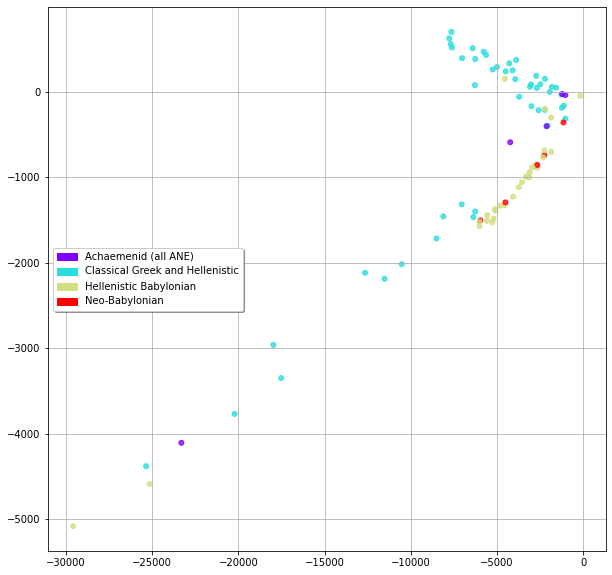

```
EPOCH 182/ 200: AE_LOSS: 0.1878 DC_LOSS: 100.0000 GEN_LOSS: 0.0000
EPOCH 183/ 200: AE_LOSS: 0.2244 DC_LOSS: 100.0000 GEN_LOSS: 0.0000
EPOCH 184/ 200: AE_LOSS: 0.2449 DC_LOSS: 100.0000 GEN_LOSS: 0.0000
EPOCH 185/ 200: AE_LOSS: 0.2275 DC_LOSS: 100.0000 GEN_LOSS: 0.0000
EPOCH 186/ 200: AE_LOSS: 0.2517 DC_LOSS: 100.0000 GEN_LOSS: 0.0000
EPOCH 187/ 200: AE_LOSS: 0.2688 DC_LOSS: 100.0000 GEN_LOSS: 0.0000
EPOCH 188/ 200: AE_LOSS: 0.2299 DC_LOSS: 100.0000 GEN_LOSS: 0.0000
EPOCH 189/ 200: AE_LOSS: 0.2384 DC_LOSS: 100.0000 GEN_LOSS: 0.0000
EPOCH 190/ 200: AE_LOSS: 0.1932 DC_LOSS: 100.0000 GEN_LOSS: 0.0000
EPOCH 191/ 200: AE_LOSS: 0.2684 DC_LOSS: 100.0000 GEN_LOSS: 0.0000
EPOCH 192/ 200: AE_LOSS: 0.1887 DC_LOSS: 100.0000 GEN_LOSS: 0.0000
EPOCH 193/ 200: AE_LOSS: 0.2342 DC_LOSS: 100.0000 GEN_LOSS: 0.0000
EPOCH 194/ 200: AE_LOSS: 0.2057 DC_LOSS: 100.0000 GEN_LOSS: 0.0000
EPOCH 195/ 200: AE_LOSS: 0.2367 DC_LOSS: 100.0000 GEN_LOSS: 0.0000
EPOCH 196/ 200: AE_LOSS: 0.2339 DC_LOSS: 100.0000 GEN_LOSS: 0.0000
EPOCH 197/ 200: AE_LOSS: 0.2126 DC_LOSS: 100.0000 GEN_LOSS: 0.0000
EPOCH 198/ 200: AE_LOSS: 0.1988 DC_LOSS: 100.0000 GEN_LOSS: 0.0000
EPOCH 199/ 200: AE_LOSS: 0.2365 DC_LOSS: 100.0000 GEN_LOSS: 0.0000
EPOCH 200/ 200: AE_LOSS: 0.2569 DC_LOSS: 100.0000 GEN_LOSS: 0.0000
Wall time: 10h 34min 51s
```

```python
%%time
iterations = EPOCHS
total_steps = 0
# TODO: optionally load the checkpoint data here from previous run

# Start training loop
for step in range(iterations):
    total_steps = total_steps+1

    for i, (imgs, y_imgs) in enumerate(dataloader):

        autoencoder_optimizer.zero_grad()
        encoder_optimizer.zero_grad()
        discriminator_optimizer.zero_grad()

        x_input = torch.reshape(imgs, [-1,input_dim])

        encoder_output = encoder(x_input)
        decoder_output = decoder(encoder_output)

        # Autoencoder loss
        autoencoder_loss = torch.mean(torch.pow(x_input.detach() - decoder_output, 2))
        #Update Autoencoder
        autoencoder_loss.backward(retain_graph=True)

        real_distribution = torch.from_numpy(np.random.randn(batch_size, z_dim) * 5).float()
        d_fake = discriminator(encoder_output)
        d_real = discriminator(real_distribution)

        # Discrimminator Loss
        dc_loss_real = torch.mean(loss_fct(d_real, torch.ones_like(d_real)))
        dc_loss_fake = torch.mean(loss_fct(d_fake, torch.zeros_like(d_fake)))
        dc_loss = dc_loss_fake + dc_loss_real
        #Update Discriminator
        dc_loss.backward(retain_graph=True)



        # Generator loss
        generator_loss = torch.mean(loss_fct(d_fake, torch.ones_like(d_fake)))
        generator_loss.backward()

        autoencoder_optimizer.step()
        discriminator_optimizer.step()
        encoder_optimizer.step()

    print('EPOCH{:4d}/{:4d}: AE_LOSS: {:.4f} DC_LOSS: {:.4f} GEN_LOSS: {:.4f}'.format(total_steps, iterations, autoencoder_loss.item(), dc_loss.item(), generator_loss.item()))

    if step % 20 == 0:
        generate_image_grid(step)
```

```python
torch.save({'state_dict': autoencoder.state_dict()}, 'models/autoencoder.pth')
torch.save({'state_dict': discriminator.state_dict()}, 'models/discriminator.pth')
torch.save({'state_dict': decoder.state_dict()}, 'models/decoder.pth')
torch.save({'state_dict': encoder.state_dict()}, 'models/encoder.pth')
```

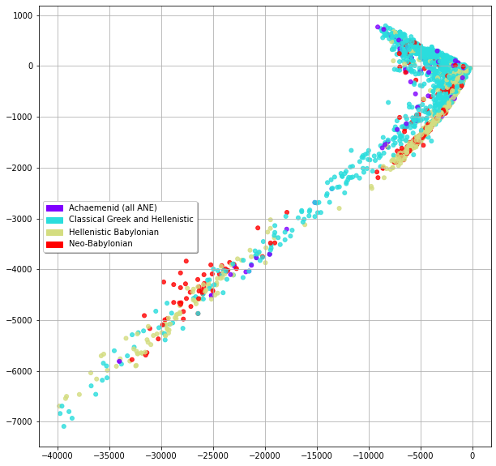

[output not shown]

[output cut: 2814 more lines]

[output not shown]

```python
generate_image_grid_final('final_image')
```

#### REFERENCES

1. S. M. Langin-Hooper,Introduction. Cambridge University Press, 2020,p. 1–12.
2. H. D. Baker, “The neo-babylonian empire,”A Companion to the Archae-ology of the Ancient Near East, vol. 1, pp. 914–931, 2012.
3. B. N. Porteret al.,Images, power, and politics: Figurative aspects ofEsarhaddon’s Babylonian policy. American Philosophical Society, 1993,vol. 208.
4. A. Makhzani, J. Shlens, N. Jaitly, I. Goodfellow, and B. Frey, “Adversarialautoencoders,”arXiv preprint arXiv:1511.05644, 2015.
5. N. Nagabushan, “A wizard’s guide to adversarial autoencoders:Part 2, exploring latent space with adversarial...” Nov 2017.[Online]. Available: https://towardsdatascience.com/a-wizards-guide-to-adversarial-autoencoders-part-2-exploring-latent-space-with-adversarial-2d53a6f8a4f9